# index

STATS 220 Semester One 2023

Francesca Domanska

2023-05-21

## Introduction

I chose the Top 100 playlists from Poland, Malta and Turkey. I simply chose these three as I am Polish but also I grew up with a lot of Turkish influence in my household, therefore these types of music are interesting to me. I chose Malta as it is a somewhat geographical midpoint between the two other countries. When I was looking at these playlists, I was hoping to see somewhat crossovers between Poland and Malta, and Malta and Turkey, as I assumed the closer countries would be, the more music taste similarities there would be. I later compared the genre popularities across the countries, where I realised, that in regards to genres such as Hip-Hop/Rap, Poland and Turkey have more similar tastes, but with more niche music types such as Dance and R&B Poland and Malta were more similar.

If i was trying to find a specific same song from multiple playlists, I could use the LIKE function, this would filter out whatever I was looking for. This would look like:

```
SELECT *
FROM tbl_playlist
WHERE track_name LIKE 'Flowers';
```

If I was trying to group songs which had the same name together, I could use the GROUP BY function and then use COUNT to see how often a song appears on different playlists.This would look like:

```
SELECT track_name, COUNT (*) AS song_count
FROM tbl_playlist
GROUP BY track_id
HAVING song_count >= 2
```

## Data creations

### First data visualisation

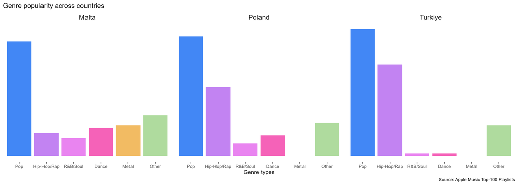

As mentioned in the Introduction, I wanted to see if geographical distance impacted the similarities in music tastes across countries. Malta is approximately 2,500km away from both Poland and Turkey, so I was expecting there to be overlaps between the countries. However, as seen in the graph, it seems that there is more overlap between Malta and Poland, and Poland and Turkey. This could be for a variety of factors such as age demographics, but it is interesting to see that genres such as Hip-Hop/Rap are quite popular in Poland and Turkey but not Malta, and that metal music seems popular in Malta. To add visual interest I added bright colours to the different types of genre, to make it more obvious which was which. I also made the background of the graph transparent so that if this graph were to be transferred to another web page, it would blend in seamlessly.

### Second data visualisation

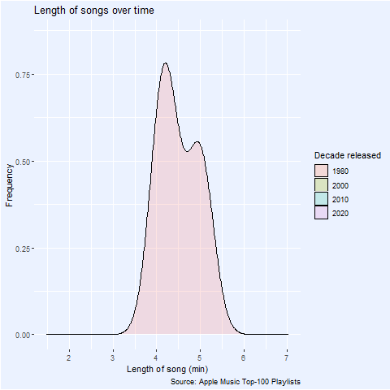

## Final reflection

An important idea I learnt from Module 5 is about joining data frames. Both the inner_join and the left_join have specific benefits of compacting and combining the data. I think being able to join data frames together based on a specific variable such as album_id is really useful. I liked learning this because it built on my knowledge from Module 3 about relational databases.

I have really enjoyed the projects as they have given me a practical application to what I have learnt from in class. Learning how to make plots using the ggplot package has probably been the most useful thing I have been able to practice as it is quite transferable to other classes where I need to make visualisations of data. It’s been really cool learning about the use of R Grammar and how to apply different components to make the graphs more interesting to look at. I also think the knowledge I gained from Module 2 to 5, has been super useful in terms of learning how to gain meaning from data that I have extracted. Specifically for Module 4, it was interesting how there was actually a lot of data and information I could analyse from my emails. Not only were the things I learned useful for this class, but gaining a better understanding of how to use R Studio has helped me in other courses such as STATS201 and BIOSCI220. I would like to continue to work on my web scraping skills. I have found it quite easy to extract and manipulate data from information gained in csv files, however I need some more practice in web scraping when I’m using the map_df() function to tie different data frames together.

## Appendix

```r
library(tidyverse)
library(rvest)
library(lubridate)

urls <- paste0(c("https://music.apple.com/us/playlist/top-100-poland/pl.8c91cbb0ef4e48308dbbba4238135eaf", "https://music.apple.com/us/playlist/top-100-malta/pl.06ab782ba2324ae49317d6bde84eef56", "https://music.apple.com/us/playlist/top-100-t%C3%BCrkiye/pl.f3e0d6ef238542609572c18b0de1513b")) %>%
  view()

# Poland Playlist
#https://music.apple.com/us/playlist/top-100-poland/pl.8c91cbb0ef4e48308dbbba4238135eaf

# Malta Playlist
#https://music.apple.com/us/playlist/top-100-malta/pl.06ab782ba2324ae49317d6bde84eef56

# Singapore Playlist
#https://music.apple.com/cy/playlist/top-100-singapore/pl.4d763fa1cf15433b9994a14be6a46164

# Creating song_data
song_data <- map_df(1 : nrow(urls), function(i){

  #combining url data together
  print(i)

  Sys.sleep(2)

  #creating variable playlist_url
  playlist_url <- urls$x[i]
  page <- read_html(playlist_url)

  #creating variable track_id
  track_id <- page %>%
    html_elements(".songs-list") %>%
    html_elements("a") %>%
    html_attr("href") %>%
    .[str_detect(., "/song/")] %>%
    str_remove_all("https://(.*)/song/(.*)/")

  #creating variable track_ranking
  track_ranking <- page %>%
    html_elements(".songs-list-row__rank") %>%
    html_text2()

  #creating variable track_name
  track_name <- page %>%
    html_elements(".songs-list-row__song-name") %>%
    html_text2()

  #creating variable artist_name
  artist_name <- page %>%
    html_elements(".songs-list-row__by-line") %>%
    html_text2()

  #creating variable album_id (later will use to join data frames)
  album_id <- page %>%
    html_elements(".songs-list__col.songs-list__col--tertiary") %>%
    html_elements(".songs-list__song-link-wrapper") %>%
    html_elements("a") %>%
    html_attr("href") %>%
    str_remove_all("https://(.*)/album/(.*)/")

  #creating variable song_length and using function from lubridate
  song_length <- page %>%
    html_elements(".songs-list-row__controls") %>%
    html_text2() %>%
    str_remove_all("PREVIEW") %>%
    str_remove_all("\n") %>%
    ms() %>%
    as.numeric()

  #combining variables together to create tabble
  tibble(playlist_url, track_id, track_ranking, track_name, artist_name, album_id, song_length) %>%
    view()

})

#Saving the data frame as RDS
saveRDS(song_data, "song_data.rds")
```

```r
library(tidyverse)
library(rvest)
library(lubridate)

# Reading the data frame
song_data <- readRDS("song_data.rds") %>%
  view

#ALBUM SCRAPING
album_data <- map_df(1 : nrow(song_data), function(i){

  #combining album data together
  print(i)

  Sys.sleep(2)

  #creating variable album ids and using function unique()
  album_ids <- song_data$album_id[i] %>% unique()
  album_url <- paste0("https://music.apple.com/album/", album_ids)
  page <- read_html(album_url)

#Creating variable album info to source release date
album_info <- page %>%
    html_elements(".footer-body") %>%
    html_elements(".description") %>%
    html_text() %>%
    str_split("\n") %>%
    unlist()

#Creating variable album_name
album_name <- page %>%
  html_elements(".headings__title") %>%
  html_text2()

#Creating variable genre_type
genre_type <- page %>%
  html_elements(".headings__metadata-bottom") %>%
  html_text2()

#Converting character date into date
album_release_date <- album_info[1] %>%
  mdy()

#Creating a data frame with variables
tibble(album_ids, album_name, genre_type, album_release_date) %>%
  view()

})

# Combining the two data frames (album and song)
playlist_data <- left_join(song_data, album_data,
                           by = c("album_id" = "album_ids")) %>%
  # Saving as new data frame
  distinct_all() %>%
  saveRDS("playlist_data.rds")

view(playlist_data)
```

```r
library(tidyverse)
library(rvest)
library(ggplot2)
library(gganimate)
library(ggpubr)

# Mutating and selecting data, also using strngr package
playlist_data <- readRDS("playlist_data.rds") %>%
  rename(date = album_release_date) %>%
  mutate(country = case_when(
    str_detect(playlist_url, "poland") ~ "Poland",
    str_detect(playlist_url, "malta") ~ "Malta",
    str_detect(playlist_url, "kiye") ~ "Turkiye",
    TRUE ~ "other")) %>%
  mutate(genre_low = str_to_lower(genre_type)) %>%
  mutate(genre = case_when(
    str_detect(genre_low, "pop") ~ "Pop",
    str_detect(genre_low, "hip-hop/rap|alternative rap|rap") ~ "Hip-Hop/Rap",
    str_detect(genre_low, "dance") ~ "Dance",
    str_detect(genre_low, "r&b/soul") ~ "R&B/Soul",
    str_detect(genre_low, "metal") ~ "Metal",
    TRUE ~ "Other")) %>%
  mutate(year_groups = case_when(
    str_detect(date, "198") ~ 1980,
    str_detect(date, "199") ~ 1990,
    str_detect(date, "200") ~ 2000,
    str_detect(date, "201") ~ 2010,
    str_detect(date, "202") ~ 2020)) %>%
  select(track_name, date, country, genre, song_length, year_groups) %>%
  view()

#Using to order genre for bar graph
genre_order <- playlist_data %>%
  c("Pop", "Hip-Hop/Rap", "R&B/Soul", "Dance", "Metal", "Other")

# Creating static visualisation
song_vis <- playlist_data %>%
  ggplot() +
  geom_bar(aes(x = factor(genre, genre_order),
               fill = factor(genre, genre_order))) +
  scale_fill_manual(values=c("#4287f5", "#c283f2", "#e984f0", "#f562b8", "#f2bb63", "#afdb9e")) +
  scale_y_continuous(NULL, breaks = NULL) +
  facet_wrap(vars(country)) +
  theme(panel.background = element_rect(fill="transparent"),
        plot.background = element_rect(fill="transparent", color=NA),
        panel.grid.major = element_blank(),
        panel.grid.minor = element_blank(),
        strip.background = element_blank(),
        strip.text = element_text(size = 13),
        legend.position = "none") +
labs(title = "Genre popularity across countries",
     x = "Genre types",
     caption = "Source: Apple Music Top-100 Playlists")
song_vis

#Saving graph as png
ggsave("song_vis.png", width = 14, height = 5, units = "in")

#Using to order decades for density graph
decade_order <- playlist_data %>%
  c(1980, 1990, 2000, 2010, 2020)

#Converting song time from seconds to minutes
song_min <- playlist_data$song_length/60

#Creating second visualisation
anim <- playlist_data %>%
  ggplot(aes(song_min, fill = factor(year_groups, decade_order))) +
  geom_density(alpha=.2) +
  labs(title = "Length of songs over time",
       x = "Length of song (min)",
       y = "Frequency",
       fill = "Decade released",
       caption = "Source: Apple Music Top-100 Playlists") +
  theme(panel.background = element_rect(fill="#ebf2ff"),
        plot.background = element_rect(fill="#ebf2ff"),
        legend.background = element_rect(fill = "#ebf2ff"))
anim +
  transition_states(year_groups,
                    transition_length = 2,
                    state_length = 1) +
  ease_aes('linear')

#Saving the animation
anim_save("song_length.gif", format = gif, width = 12, height = 5, units = "in")
```

## Redemption

In Project 3, I lost a mark as I set the echo = TRUE, when it was stated I should set it to FALSE. This was a silly mistake I made, as I had been confused about where code should have been visible (i.e. the Appendix) and where it should not have been.

In Project 3 I did this:

```
knitr::opts_chunk$set(echo = TRUE, message = FALSE, error = FALSE, warning = FALSE)
```

When it should have looked like this:

```
knitr::opts_chunk$set(echo = FALSE, message = FALSE, error = FALSE, warning = FALSE)
```

In all honesty, I previously did not know what the different functions for knitr meant, however I now know that echo is responsible for whether code will be shown/hidden in the final document. Message is responsible for preventing messages that are generated by code from appearing in the final document. Error allows or prevents R to running when there is an error in the code chunks, and warning allows/prevents warning messages from appearing in the final document.